# Polygenic Scores Workshop: Evaluation of Polygenic Scores in R

Jodi T Thomas

15 July, 2026

# Load Packages

```r
library(knitr)        # for kable tables
library(performance)  # for model checking
library(DHARMa)       # for model checking
library(effects)      # for nice summary of model results (allEffects)
library(broom.mixed)  # for tidy output
library(ggplotify)    # to use patchwork on lattice plots (created by allEffects)
library(MuMIn)        # to calculate R2
library(pROC)         # for ROC curves and AUC
library(patchwork)    # for combining ggplot plots
library(tidyverse)
```

# Load Data

```r
# Update this when have final results from workshop:
PGS_df <- read.table(file = "/path/PGS_Workshop/01_Create_PGS/Plink_PGS_scores/ILAE3_Caucasian_all_epilepsy_EUR.QC_PGS_scores.profile", header = T)

# Read in covariates data
cov_df <- read.table(file = "/path/PGS_Workshop/Genotype_data/EUR.cov", header = T)

# Read in ancestry PCs data
PCs_df <- read.table(file = "/path/PGS_Workshop/Genotype_data/EUR.eigenvec", header = F, col.names = c("FID", "IID", "PC1", "PC2", "PC3", "PC4", "PC5", "PC6"))

# Relatedness data
related_df <- read.table(file = "/path/PGS_Workshop/02_Evaluate_PGS/EUR_relatedness.genome", header = T)
```

# Tidy Data

```r
# Merge these three dataframes (PGS, covariates and PCs) and add simulated data for our phenotype = epilepsy (case/control)

set.seed(123) # set seed for reproducibility
Df <- PGS_df %>%
  left_join(cov_df) %>%
  left_join(PCs_df) %>%
  mutate(
    lp = -1.5 + 0.8 * scale(SCORESUM) +
      0.05 * Sex + 0.01 * PC1 + 0.005 * PC2 +
      0.005 * PC3 + 0.00001 * PC4 + 0.0003 * PC5 + 0.00008 * PC6,
    prob = plogis(lp),
    Epilepsy = rbinom(n(), size = 1, prob = prob)) %>%
  select(-c(lp, prob))



# Remove 1 individual from each pair that have pi_hat > 0.1875 with controls preferentially removed.
# This removes individuals that are first- and second-degress relatives (0.1875 is halfway between 2nd and 3rd degree relatives)
# Note in our data that related_df is empty - no individuals have pi_hat > 0.09 (this dataset was QCed and related individuals were already removed)
# So this code is commented out, but you can use it if your data includes related individuals

# # Df with case/ctrl status for each IID
# Epilepsy_status <- Df %>%
#   select(IID, Epilepsy)
#
# # Join related df with CP Epilepsy_status so have case/control status for both IID1 and IID2
#
# related_epilepsy_status <- related_df %>%
#   left_join(Epilepsy_status, by = c("IID1" = "IID")) %>%
#   rename(Epilepsy_IID1 = Epilepsy) %>%
#   left_join(Epilepsy_status, by = c("IID2" = "IID")) %>%
#   rename(Epilepsy_IID2 = Epilepsy)
#
# # Filter pairs with PI_HAT > 0.1875, preferentially removing controls and keeping cases
# related_remove <- related_epilepsy_status %>%
#   filter(PI_HAT > 0.1875) %>%
#   rowwise() %>%
#   mutate(
#     remove = case_when(
#       Epilepsy_IID1 == 0 & Epilepsy_IID2 == 1 ~ IID1,  # Prefer removing control (IID1)
#       Epilepsy_IID1 == 1 & Epilepsy_IID2 == 0 ~ IID2,  # Prefer removing control (IID2)
#       Epilepsy_IID1 == 0 & Epilepsy_IID2 == 0 ~ sample(c(IID1, IID2), 1),  # Randomly remove one if both are controls
#       Epilepsy_IID1 == 1 & Epilepsy_IID2 == 1 ~ sample(c(IID1, IID2), 1)   # Randomly remove one if both are cases
#     )
#   ) %>%
#   select(remove)
#
# # Remove these individuals from df
# Df <- Df %>%
#   anti_join(related_remove, by = join_by("IID" == "remove"))

save(Df, file = "Data/Df.Rdata")
```

# Logistic Regression

- Determine direction and strength of relationship between outcome (epilepsy case/control) and predictor (PGS for epilepsy)
- Is there a significant association between outcome and predictor?

## Explore Data

- Data exploration before fitting model

```r
# Data exploration before fitting regression models

# Check PGS before and after standardisation
Df %>%
  summarise(
    mean_PRS = mean(SCORESUM, na.rm = TRUE),
    sd_PRS = sd(SCORESUM, na.rm = TRUE),
    mean_PRS_standardised = mean(scale(SCORESUM), na.rm = TRUE),
    sd_PRS_standardised = sd(scale(SCORESUM), na.rm = TRUE)) %>%
  kable()
```

| mean_PRS | sd_PRS | mean_PRS_standardised | sd_PRS_standardised |
| --- | --- | --- | --- |
| -0.0276058 | 0.0128811 | 0 | 1 |

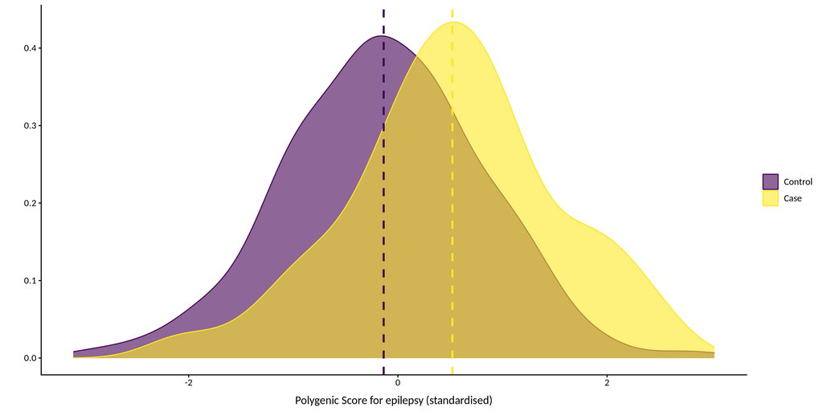

```r
# Plot distribution of standardised PGS split by epilepsy case/control
means <- Df %>%
  mutate(SCORESUM_scaled = scale(SCORESUM)) %>%
      group_by(Epilepsy) %>%
      summarise(mean_value = mean(SCORESUM_scaled, na.rm = TRUE))
labels <- c("1" = "Case", "0" = "Control")

ggplot(Df, aes(x = scale(SCORESUM), colour = as.factor(Epilepsy), fill = as.factor(Epilepsy))) +
      geom_density(alpha = 0.6, position = "identity") +
      geom_vline(data = means, aes(xintercept = mean_value, colour = as.factor(Epilepsy)),
                 linetype = "dashed", linewidth = 1, alpha = 1,
                 show.legend = F) +
      scale_colour_viridis_d(name = "Epilepsy", labels = labels) +
      scale_fill_viridis_d(name = "Epilepsy", labels = labels) +
      scale_x_continuous(paste("Polygenic Score for epilepsy (standardised)")) +
      scale_y_continuous("") +
      theme_classic() +
      theme(text = element_text(family = "Calibri"),
            axis.text = element_text(size = 10),
            axis.title.x = element_text(size = 12, colour = "black", margin = margin(10,0,0,0)),
            axis.title.y = element_text(size = 12, colour = "black", margin = margin(0,10,0,0)),
            legend.title = element_blank(),
            legend.text = element_text(size = 10, colour = "black"),
            legend.position = "right")
```

## Fit Models

```r
logistic_regression_covar <- glm(Epilepsy ~ Sex + PC1 + PC2 + PC3 + PC4 + PC5 + PC6,
                               family = binomial(link = 'logit'),
                               data = Df)

logistic_regression_PGS <- glm(Epilepsy ~ scale(SCORESUM) + Sex + PC1 + PC2 + PC3 + PC4 + PC5 + PC6,
                           family = binomial(link = 'logit'),
                           data = Df)

save(logistic_regression_covar, logistic_regression_PGS, file = "Results/logistic_regression_models.Rdata")
```

## Check Models

- Check model assumptions are met

### Covariates only model

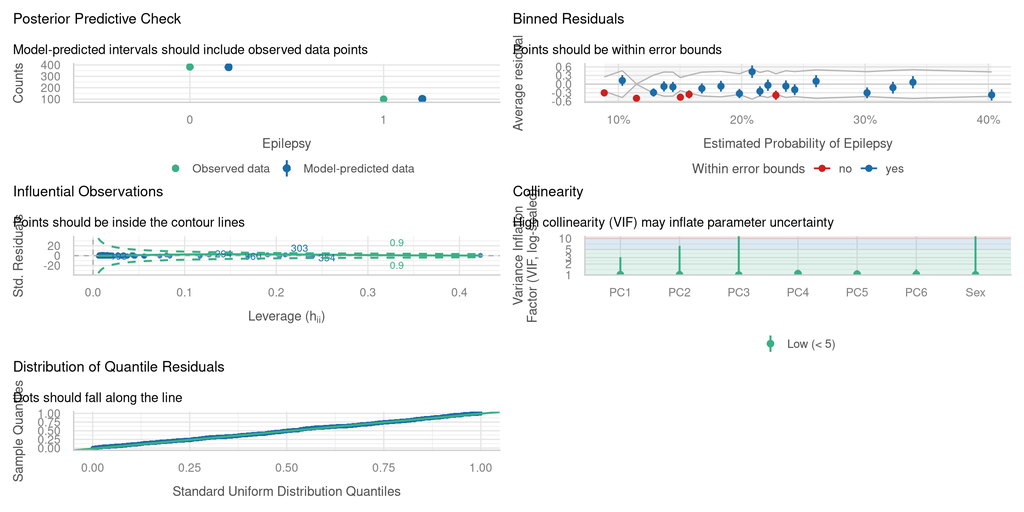

```r
performance::check_model(logistic_regression_covar)
```

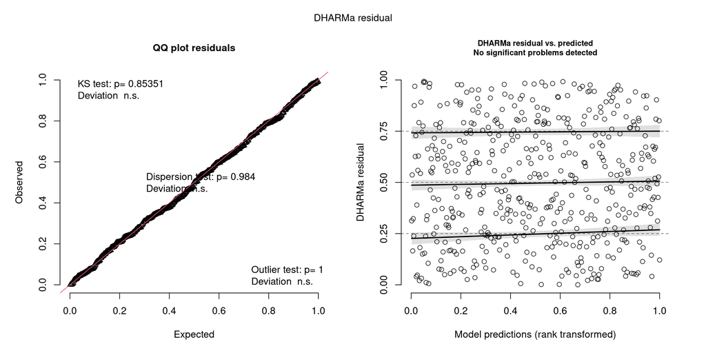

```
## Object of Class DHARMa with simulated residuals based on 250 simulations with refit = FALSE . See ?DHARMa::simulateResiduals for help.
##
## Scaled residual values: 0.4934136 0.3712214 0.7600724 0.9030907 0.9147184 0.5070392 0.4759453 0.8087139 0.6707893 0.427792 0.9515216 0.6071721 0.3766932 0.2796808 0.3484822 0.8634359 0.6777244 0.6038602 0.4524239 0.8960244 ...
```

```r
simulateResiduals(logistic_regression_covar, plot=TRUE)
```

### Full model including PGS

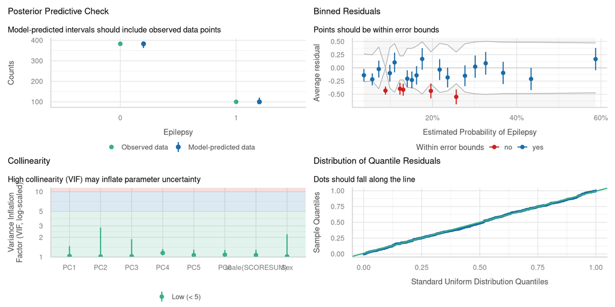

```r
performance::check_model(logistic_regression_PGS)
```

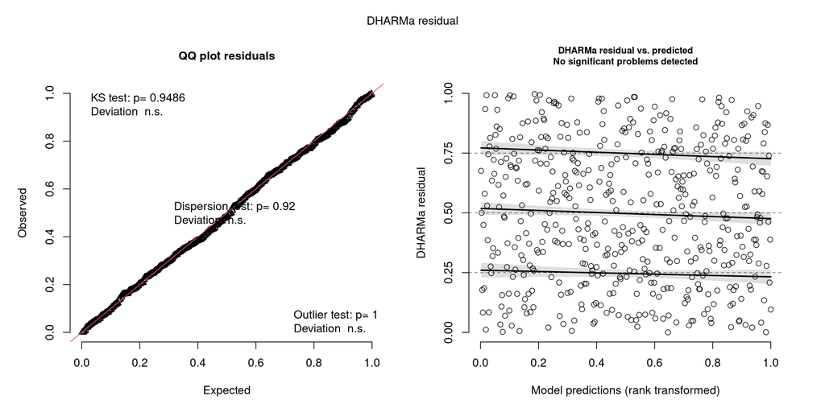

```
## Object of Class DHARMa with simulated residuals based on 250 simulations with refit = FALSE . See ?DHARMa::simulateResiduals for help.
##
## Scaled residual values: 0.6002675 0.4242531 0.868103 0.9209672 0.9702806 0.7054458 0.6221695 0.8068746 0.3881337 0.5932049 0.9464849 0.6106817 0.3835009 0.3789757 0.4396549 0.8727471 0.8356034 0.7685494 0.4018737 0.8780976 ...
```

```r
simulateResiduals(logistic_regression_PGS, plot=TRUE)
```

## Results

- Check odds ratio - is the relationship between epilepsy (case/control) and PGS for epilepsy in the expected direction (i.e. positive, so an OR > 1)?
  - If the relationship is in the opposite direction to what is expected, check that the columns for effect allele and other allele were correct (and not flipped) in the GWAS summary statistics used to make the PGS

### Table

```r
tidy(logistic_regression_PGS, conf.int = TRUE, conf.level = 0.95, exponentiate = TRUE) %>%
  filter(str_detect(term, "SCORESUM")) %>%
  kable(caption = "Results from logistic regression (back-transformation conducted so estimate = odds ratio")
```

Results from logistic regression (back-transformation conducted so estimate = odds ratio

| term | estimate | std.error | statistic | p.value | conf.low | conf.high |
| --- | --- | --- | --- | --- | --- | --- |
| scale(SCORESUM) | 1.996967 | 0.132798 | 5.20813 | 2e-07 | 1.549091 | 2.610149 |

### Graph

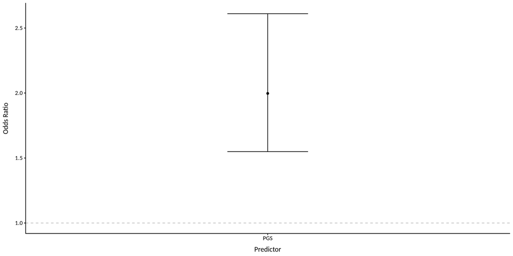

```r
or_table <- tidy(logistic_regression_PGS, exponentiate = TRUE, conf.int = TRUE, conf.level = 0.95,) %>%
  filter(str_detect(term, "SCORESUM")) %>%
  mutate(
    term = str_replace(term, "scale\\(SCORESUM\\)", "PGS"),
    sig_label = ifelse(p.value < 0.05, "*", "")
  )

ggplot(or_table, aes(x = term, y = estimate)) +
  geom_hline(yintercept = 1, linetype = "dashed", color = "gray") +
  geom_point() +
  geom_errorbar(aes(ymin = conf.low, ymax = conf.high), width = 0.2) +
  scale_y_continuous("Odds Ratio") +
  scale_x_discrete("Predictor") +
  # geom_text(aes(label = sig_label, y = conf.high + 0.05), size = 6) +
  theme_classic() +
  theme(
    text = element_text(family = "Calibri"),
    axis.text = element_text(size = 10),
    axis.title.x = element_text(size = 12, colour = "black", margin = margin(10, 0, 0, 0)),
    axis.title.y = element_text(size = 12, colour = "black", margin = margin(0, 10, 0, 0)),
    legend.title = element_blank(),
    legend.text = element_text(size = 10, colour = "black"),
    legend.position = "right"
  )
```

# Nagelkerke’s R<sup>2</sup>

- Estimate Nagelkerke’s R<sup>2</sup> attributable to the polygenic score (PGS) = Nagelkerke’s R<sup>2</sup>(full model) - Nagelkerke’s R<sup>2</sup>(covariates only model)
- As we’re using a binary trait and a logistic regression we use a pseudo-R<sup>2</sup> value, here Nagelkerke’s R<sup>2</sup>
- Nagelkerke’s R<sup>2</sup> is is an adjusted version of Cox and Snell’s R<sup>2</sup>, scaled to a range of 0 to 1 for easier interpretation
- However, as a pseudo R<sup>2</sup>, this value cannot be interpreted as the proportion of variance explained in the same way R<sup>2</sup> is used in a linear regression.
- Instead this pseudo R<sup>2</sup> is a relative measure of model fit, representing an approximation of explained variance:
  - 0 means the model explains none of the variation in the outcome
  - 1 means the model explains all the variation in the outcome
- You can use some general thresholds to interpret Nagelkerke’s R<sup>2</sup> (these thresholds can change across fields). E.g. :
  - 0 - 0.1: weak explanatory power
  - 0.1 - 0.3, moderate explanatory power
  - 0.3 - 0.5, strong explanatory power
  - > 0.5 very strong explanatory power
- Nagelkerke’s R<sup>2</sup> is calculated on the observed binary scale
  - Depends on the case/control ratio in your sample
  - Cannot be compared across studies with different case/control ascertainment
  - Is not comparable to SNP-based heritability

```r
r2_PGS <- r2_nagelkerke(logistic_regression_PGS) - r2_nagelkerke(logistic_regression_covar)

r2_PGS %>%
  kable(caption = "Nagelkerke's R2 attributable to the PGS")
```

Nagelkerke’s R2 attributable to the PGS

|  | x |
| --- | --- |
| Nagelkerke’s R2 | 0.0917951 |

# R<sup>2</sup> on the Liability Scale

- Variance in the outcome variable risk explained on the liability scale, attributable to the PGS
- We run linear regressions, even though our outcome is binary, to calculate R<sup>2</sup> for our covariates + PGS model and covariates only model
- This R<sup>2</sup> is on the observed scale
  - It is biased by case/control ratio in your sample
- So we adjust R<sup>2</sup> to the liability scale, which reflects a latent (normally distributed) trait underlying disease risk.
- For more details, see publication: Lee SH, et al., A Better Coefficient of Determination for Genetic Profile Analysis. Genetic Epidemiology, 2012. 36(3):214-224
- Observed R<sup>2</sup>: tells you how well your PGS predicts actual case/control status in your sample.
- Liability R<sup>2</sup>: tells you how much of the underlying genetic liability is explained by your PGS, standardized to population-level risk.
  - This is critical if you want to compare PGS performance across studies
  - Liability R<sup>2</sup> is comparable to SNP-based heritability estimates, e.g. as estimated from using GWAS summary statistics in LDSC software
- Then do Liability R<sup>2</sup>(covariates + PGS) - Liability R<sup>2</sup> (covariates only) to calculate Liability R<sup>2</sup> attributable to the PGS

## Calculate Vairance explained on Liability Scale

- Function to convert observed R<sup>2</sup> to R<sup>2</sup> on liability scale
- From Lee SH, et al., A Better Coefficient of Determination for Genetic Profile Analysis. Genetic Epidemiology, 2012. 36(3):214-224

```r
# Variance explained by the PGS on the liability scale

# Convert observed R2 to the liability scale using poopulation prevalence of your disease/condition
# Use R code from Lee SH, et al., A Better Coefficient of Determination for Genetic Profile Analysis. Genetic Epidemiology, 2012. 36(3):214-224.
# Made into a function
# lm = linear model
# K = population prevalence
# P = sample prevalence

mapToLiabilityScale = function(lm, K, P){
  thd = qnorm(1 - K) # the threshold on the normal distribution which truncates the proportion of disease prevalence K
  zv = dnorm(thd) # z (normal density)
  mv = zv/K # mean liability for case
  mv2 = -mv*K/(1-K) # mean liability for control

  y = lm$model[[1]]
  ncase = sum(y == 1)
  nt = length(y)
  ncont = nt - ncase
  R2O = var(lm$fitted.values)/(ncase/nt*ncont/nt) # R2 on the observed scale

  theta = mv*(P-K)/(1-K)*(mv*(P-K)/(1-K)-thd) # theta in equation 15 of the publication
  cv = K*(1-K)/zv^2*K*(1-K)/(P*(1-P)) # C in equation 15 of the publication
  R2 = R2O*cv/(1+R2O*theta*cv)

  return(R2)
}
```

- Fit linear models to calculate observed R<sup>2</sup> for model with covariates only and model with caovariates + PGS
- Convert observed R<sup>2</sup> to R<sup>2</sup> on liability scale using above function
- Calculate R<sup>2</sup> (liability) attributable to PGS = R<sup>2</sup> (liability) (covariates + PGS) - R<sup>2</sup> (liability) (covariates only)
- Run bootstrapping to calculate confidence intervals

```r
# Calculate difference in R2 on liability scale of full model - covariates only model to identify variance attributable to PGS
# Bootstrap to get 90% CI
# Doing a one-sided test of significance (> 0) therefore use a one-sided 95% CI (equivalent to just the lower bound of a 90% CI)

set.seed(123)  # for reproducibility
n_boot <- 1000

r2_diffs <- numeric(n_boot)

for (i in 1:n_boot) {
      # Resample data with replacement
      boot_data <- Df[sample(1:nrow(Df), replace = TRUE), ]

      # Fit models with resampled data
      lm_covar <- lm(Epilepsy ~ Sex + PC1 + PC2 + PC3 + PC4 + PC5 + PC6,
                   data = boot_data)

      lm_full <- lm(Epilepsy ~ SCORESUM + Sex + PC1 + PC2 + PC3 + PC4 + PC5 + PC6,
                    data = boot_data)

      # Calculate sample prevalence in the bootstrap sample
      ncase <- sum(boot_data$Epilepsy == 1)
      P_boot <- ncase / nrow(boot_data)

      # Liability R² (using lifetime population prevalence K as 0.012 (1.2%))
      r2_covar <- mapToLiabilityScale(lm_covar, K = 0.012, P = P_boot)
      r2_full <- mapToLiabilityScale(lm_full, K = 0.012, P = P_boot)

      r2_diffs[i] <- r2_full - r2_covar
    }

save(r2_diffs, file = "Results/r2_liability_attributable_PGS_bootstrapping.Rdata")
```

## Results Table

```r
# Doing a one-sided test of significance (> 0) therefore use a one-sided 95% CI (equivalent to just the lower bound of a 90% CI)
n_boot <- 1000
tibble(
  r2l_mean = mean(r2_diffs),
  r2l_SE = sd(r2_diffs) / sqrt(n_boot),
  r2l_Z = r2l_mean / r2l_SE,
  r2l_p = pnorm(r2l_Z, mean = 0, sd = 1, lower.tail = F),
  r2l_90perc_CI_lower = quantile(r2_diffs, 0.05),
  r2l_90perc_CI_upper = quantile(r2_diffs, 0.95)) %>%
  kable(caption = "Variance explained in epilepsy risk on the liability scale attributable to epilepsy PGS and one-sided test of significance if R2 (liability) attributable to PGS is > 0")
```

Variance explained in epilepsy risk on the liability scale attributable to epilepsy PGS and one-sided test of significance if R2 (liability) attributable to PGS is > 0

| r2l_mean | r2l_SE | r2l_Z | r2l_p | r2l_90perc_CI_lower | r2l_90perc_CI_upper |
| --- | --- | --- | --- | --- | --- |
| 0.0609973 | 0.0006948 | 87.79185 | 0 | 0.0278923 | 0.0995844 |

# Odds Ratio by Decile of PGS

- Cut the distribution of PGS into deciles, with each decile containing cases and controls
- Calculate the odds ratio of each PGS decile compared to the first (lowest) PGS decile or the middle (5th and 6th) deciles
- This is a practical and interpretable way to visualise that there could be utility in using high vs low PGS
- But this method also doesn’t take into account the proportion of cases and controls in your data - it will look much more impressive if you have a data set with 50% cases and 50% controls, compared to a population sample.

## Create PGS Decile Data

```r
# Create deciles of PGS and set first decile as the reference/base group
Df_lowest <- Df %>%
  mutate(
    PGS_decile = ntile(scale(SCORESUM), 10),
    PGS_decile = factor(PGS_decile, levels = 1:10)
  )

# Create deciles of PGS and set middle deciles as the reference/base group
Df_mid <- Df %>%
  mutate(
    PGS_decile = ntile(scale(SCORESUM), 10),
    PGS_decile = case_when(
      PGS_decile %in% c("5", "6") ~ "5_6",
      TRUE ~ as.character(PGS_decile)
    ),
    PGS_decile = factor(PGS_decile, levels = c('5_6','1','2','3','4','7','8','9','10'))
  )
```

## Fit Model

```r
# Run logistic regression with the PGS decile as the predictor
decile_model_lowest <- glm(Epilepsy ~ PGS_decile + Sex + PC1 + PC2 + PC3 + PC4 + PC5 + PC6,
                    family = binomial(link = 'logit'),
                    data = Df_lowest)

decile_model_mid <- glm(Epilepsy ~ PGS_decile + Sex + PC1 + PC2 + PC3 + PC4 + PC5 + PC6,
                        family = binomial(link = 'logit'),
                        data = Df_mid)

save(decile_model_lowest, decile_model_mid, file = "Results/decile_model.Rdata")
```

## Check Model

### Reference: Lowest decile

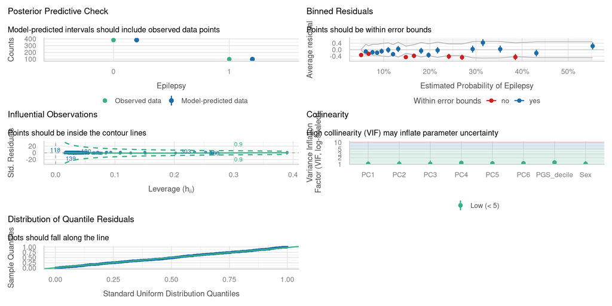

```r
performance::check_model(decile_model_lowest)
```

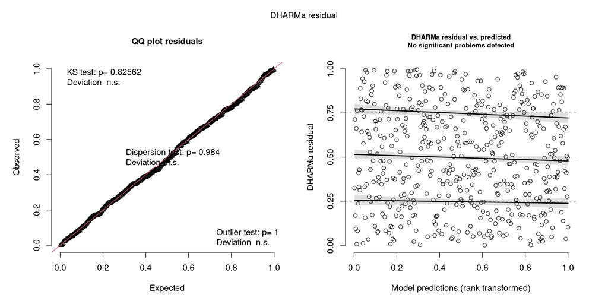

```
## Object of Class DHARMa with simulated residuals based on 250 simulations with refit = FALSE . See ?DHARMa::simulateResiduals for help.
##
## Scaled residual values: 0.6599799 0.4262172 0.8565282 0.9190854 0.956067 0.6361609 0.5877638 0.7664102 0.4978706 0.5589815 0.9515216 0.6141914 0.3903086 0.3425676 0.4254725 0.8836101 0.827902 0.8273669 0.3791262 0.8547927 ...
```

```r
simulateResiduals(decile_model_lowest, plot=TRUE)
```

### Reference: 5th and 6th deciles

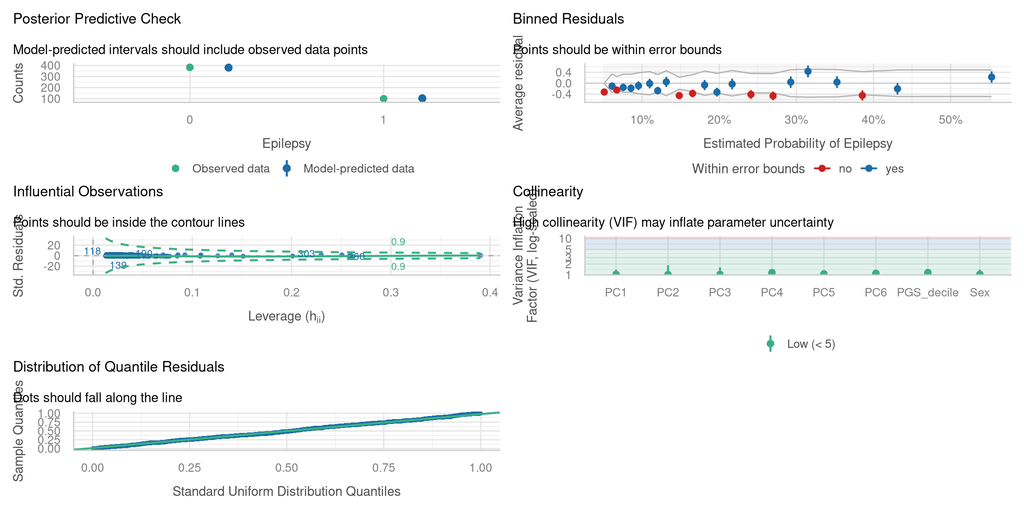

```r
performance::check_model(decile_model_mid)
```

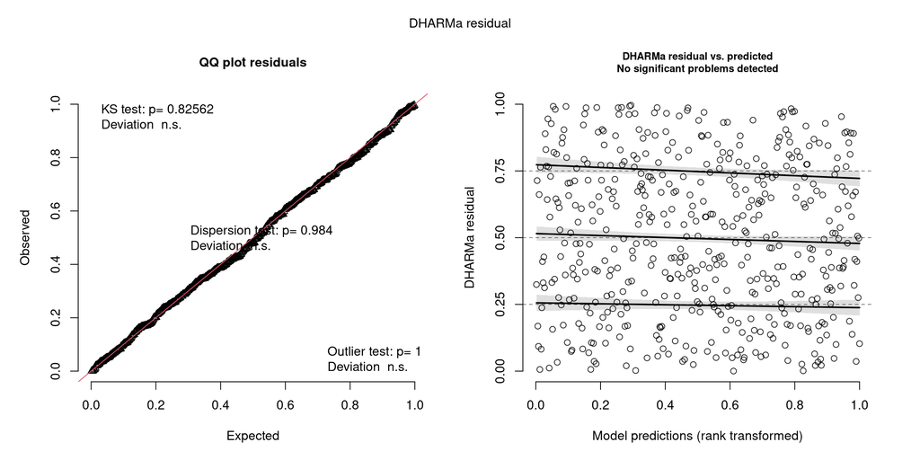

```
## Object of Class DHARMa with simulated residuals based on 250 simulations with refit = FALSE . See ?DHARMa::simulateResiduals for help.
##
## Scaled residual values: 0.6599799 0.4262172 0.8565282 0.9181446 0.956067 0.6361609 0.5877638 0.7664102 0.4978706 0.5589815 0.9521512 0.6141914 0.3903086 0.3425676 0.4254725 0.885162 0.827902 0.8273669 0.3791262 0.8547927 ...
```

```r
simulateResiduals(decile_model_mid, plot=TRUE)
```

## Results

### Reference: Lowest decile

#### Table

- Odds ratio for each PGS decile compared to the first decile
- Adjust p-value for nine tests, using Benjamini-Hochberg method

```r
tidy(decile_model_lowest, exponentiate = TRUE, conf.int = TRUE) %>%
  filter(str_detect(term, "PGS_decile")) %>%
  mutate(p.value_adjusted = p.adjust(p.value, method = "BH", n = 9)) %>%
  kable(caption = "Results from logistic regression with decile of PGS as predictor and lowest decile as the reference (Back-transformation conducted so estimate = odds ratio. P-value adjusted for 9 comparisons with Benjamini-Hochberg method)")
```

Results from logistic regression with decile of PGS as predictor and lowest decile as the reference (Back-transformation conducted so estimate = odds ratio. P-value adjusted for 9 comparisons with Benjamini-Hochberg method)

| term | estimate | std.error | statistic | p.value | conf.low | conf.high | p.value_adjusted |
| --- | --- | --- | --- | --- | --- | --- | --- |
| PGS_decile2 | 1.0397797 | 0.6744791 | 0.0578355 | 0.9538796 | 0.2681111 | 4.034661 | 0.9538796 |
| PGS_decile3 | 0.7576682 | 0.7125180 | -0.3894775 | 0.6969230 | 0.1745906 | 3.094727 | 0.8960438 |
| PGS_decile4 | 1.0903052 | 0.6761135 | 0.1278745 | 0.8982483 | 0.2803389 | 4.244004 | 0.9538796 |
| PGS_decile5 | 1.9762287 | 0.6258979 | 1.0883410 | 0.2764446 | 0.5897367 | 7.194758 | 0.4146669 |
| PGS_decile6 | 1.9932652 | 0.6078648 | 1.1347493 | 0.2564804 | 0.6224139 | 7.060147 | 0.4146669 |
| PGS_decile7 | 3.5766567 | 0.5799674 | 2.1974141 | 0.0279909 | 1.2068980 | 12.190983 | 0.0713722 |
| PGS_decile8 | 3.4580987 | 0.5776403 | 2.1479092 | 0.0317210 | 1.1722272 | 11.738597 | 0.0713722 |
| PGS_decile9 | 4.2787584 | 0.5781616 | 2.5142848 | 0.0119274 | 1.4534724 | 14.560642 | 0.0536733 |
| PGS_decile10 | 6.2002627 | 0.5691945 | 3.2055678 | 0.0013480 | 2.1592538 | 20.843482 | 0.0121317 |

#### Graph

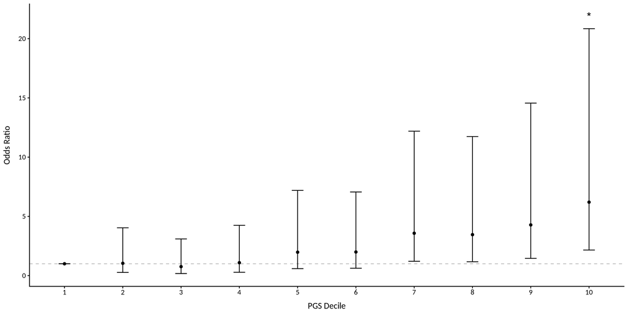

```r
or_table <- tidy(decile_model_lowest, exponentiate = TRUE, conf.int = TRUE, conf.level = 0.95,) %>%
  filter(str_detect(term, "PGS_decile")) %>%
  add_row(
    term = "PGS_decile1",
    estimate = 1,
    conf.low = 1,
    conf.high = 1,
    p.value = NA) %>%
  mutate(
    decile = str_remove(term, "PGS_decile"),
    decile = factor(decile, levels = as.character(1:10)),
    p.value_adjusted = p.adjust(p.value, method = "BH", n = 9),
    sig_label = ifelse(p.value_adjusted < 0.05, "*", "")
  )

ggplot(or_table, aes(x = decile, y = estimate)) +
  geom_hline(yintercept = 1, linetype = "dashed", color = "gray") +
  geom_point() +
  geom_errorbar(aes(ymin = conf.low, ymax = conf.high), width = 0.2) +
  scale_y_continuous("Odds Ratio") +
  scale_x_discrete("PGS Decile") +
  geom_text(aes(label = sig_label, y = conf.high + 1), size = 6) +
  theme_classic() +
  theme(
    text = element_text(family = "Calibri"),
    axis.text = element_text(size = 10),
    axis.title.x = element_text(size = 12, colour = "black", margin = margin(10, 0, 0, 0)),
    axis.title.y = element_text(size = 12, colour = "black", margin = margin(0, 10, 0, 0)),
    legend.title = element_blank(),
    legend.text = element_text(size = 10, colour = "black"),
    legend.position = "right"
  )
```